# moodleQ-man-[ENG]

## Insert files in the questionnaire

It is possible to insert documents in the question statements, usually in a first question of description type. The idea is to use the tag to embed a file encoded in *base64* in the moodle question that can then be downloaded. To do this you can use the *‘file’* tag with the constructor or directly the *addfile()* method.

The following code creates a question and inserts three files, A.csv, B.csv and C.csv for the student to download one of them.

```r
# Embed files
q1 <- question$new(
  type="multichoice",
  'name' = "P001",
  'question' = 'Choose: <a href="@@PLUGINFILE@@/A.csv">download A.csv</a> or
      <a href="@@PLUGINFILE@@/B.csv">download B.csv</a>
  <a href="@@PLUGINFILE@@/C.csv">download C.csv</a>',
  answer' = list("Answer 1", 100),
  'answer' = list("Answer 2"))



q1$addfile("./file.csv", "A.csv")
q1$addfile("./file.csv", "B.csv")

df <- data.frame(a = rnorm(10), b=rnorm(10))

tmp <- tempfile()
write.table(df, file=tmp, sep=",", dec=".")
q1$addfile(tmp, "C.csv")
unlink(tmp)
q1$xml()
```

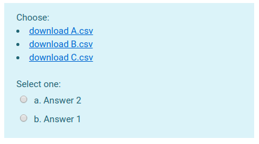

The first two files are stored on the hard disk and we incorporate them with the *addfile* method that has three arguments:

- drivePath: the path to the file in the computer
- name = NULL: the name of the file, if it is not given we use the one that has the file.
- quizPath=“/”: the relative path in the questionnaire file structure, by default “/”.

The third file is not stored in the disk, but a data.frame and an R connection is created to be stored and read from there. This allows you to have a code that generates a file for the student to download and analyze and then answer questions about it.

Notice how in the code of the question statement of the previous example the links in html have been introduced so that the files can be downloaded and how it is necessary that the url is preceded by _@@PLUGINFILE@_.

As the files are embedded with the addfile() method they can also be embedded using the constructor. The following code would do the same but from the question constructor. Sometimes one will be useful and sometimes the other.

```r
# the same work but adding to it from the builder

tmp <- tempfile()
write.table(df, file=tmp, sep=",", dec=".")
#q1$addfile(tmp, "C.csv")


q2 <- question$new(
  type="multichoice",
  'name' = "P002",
  'question' = 'Download: <a href="@@PLUGINFILE@@/A.csv">download A.csv</a> o
      <a href="@@PLUGINFILE@@/B.csv">download B.csv</a>
  <a href="@@PLUGINFILE@@/C.csv">download C.csv</a>',
  'file' = list("./fichero.csv", "A.csv"),
  'file' = list("./fichero.csv", "B.csv"),
  'file' = list(tmp, "C.csv"),
  answer' = list("Answer 1", 100),
  'answer' = list("Answer 2"))

unlink(tmp)

q2$xml()
```

In the same way that we have included .csv files you can include any type of file you want.

## Create response banks

The *calculated* type questions allow you to work with banks of answers. These are questions that accept *wildcards* or *tokens* that can be used both in the statement and in the answer alternatives. These wildcards are like variables or identifiers that accept different values. It is easier to understand with an example:

```r
q1 <- question$new(
  type="calculated",
  'name' = "P001",
  'question' = "
  With the numbers: A = {A} and B = {B}


  <p>Calculate: A + B</p>

  ",
  'answer' = list("{C}", 100),
  'dataset' = list(data.frame(A = c(1, 4))),
  'dataset' = list(data.frame(B = c(3, 2))),
  'dataset' = list(data.frame(C = c(4,6))))
```

Moodle will randomly present one of the 2 available rows, for example row 1 and will use the values of A, B and C (1, 3 and 4) for the question. When answering with number 4 the answer is marked correct.

In addition, moodle allows you to synchronize the banks of different questions with the *synchronize* option (default in moodleQ). If the subject is assigned row 1 when the questionnaire is opened, all questions will be assigned row 1, which opens interesting options.

```r
q2 <- question$new(
  type="calculated",
  'name' = "P002",
  'question' = "Calculate A * B",
  'answer' = list("{D}", 100),
  'dataset' = list(data.frame(D = c(3,8))))
```

When synchronized, if the student is assigned row 1 (values 1 and 3), the correct answers to both questions will be those in row 1: C = 4 and D = 3. This synchronization of the answers opens up the possibility of building more complex database based analyses.

An important clarification__, the calculated questions allow to associate a base entry with a subject, but it is only possible with this type of questions. If we want you to answer multiple choice questions, we have to make a compromise.

```r
q3 <- question$new(
  type="calculated",
  'name' = "P001",
  'question' = "
Calcule A - B.
<hr>
<p>Write in the answer box the number of the right statement:</p>
<u>
<li><b>1</b> = The result is positive</li>
<li><b>2</b> = The result is negative</li>
</u>
  ",
  'answer' = list("{E}", 100),
  'dataset' = list(data.frame(E = c(2, 1))))
```

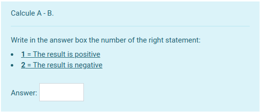

In this way the multiple choice is linked to the base assigned to the subject.

Two restrictions apply to this type of question:

- The variables can only be of a numerical type.
- You can only use tokens that have been embedded in the same question.

## Example 1: reading multiple choice questions from a file

What we do is we store a database of questions in a rich and easily readable format. To keep them organized, we include category questions. For example, we have a file with questions in markdown format in which each question forms a block separated by blank lines and where the first line is the statement, then the correct alternative and then the rest of the alternatives:

```
category tests_moodleQ

This is statement 1
Answer1.1
Answer1.2
Answer1.3

This is the second statement
Answer2.1
Answer2.2
Answer2.3
Answer2.4
```

And with a simple code you can read the previous file and pack it in a moodle quiz.

```r
lines <- readLines("./questions.md")

Q <- quiz$new()

nq = 0; i=1
while(i<=length(lines)){
  if(lines[i]=="") i = i + 1
  else if(grepl("category", lines[i])){
    nq = nq + 1
    Q$add(
      question$new(
        'type' = "category",
        'name' = sprintf("P%03d",nq),
        'category' = sprintf("$course$/%s", strsplit(lines[i], " ")[[1]][[2]]))
    i = i + 1
  } else {
    nq = nq + 1
    q <- question$new(type="multichoice",
            'name' = sprintf("P%03d",nq),
            format' = 'Markdown',
            'question' = lines[i],
            'answer' = list(lines[i+1], 100))
    j = i+2
    while(lines[j]!="" & j <= length(lines)){
      q$addanswer(list(lines[j]))
      j = j + 1
    }
    Q$add(q)
    i = j
  }
}

Q$save_xml("miquiz.xml")
```

## Example 2: a test with a common statement

In this example we are going to build a questionnaire that has a description of a problem and they have to download a file embedded in pdf. Then the questions refer to the reading of that downloaded file. All students read the same statement and share the same questions and answers.

```r
# A statement using html
myquestiontext = '
Lorem ipsum dolor sit amet, consectetur adipiscing elit. Praesent egestas urn a dapibus imperdiet. Quisque augue neque, ornare pharetra facilisis ut, ultricies eu magna. Nulla facilisi. That's what I do with my readings. Integrate pharetra sagittis luctus. Sed vel nisi eu arcu sollicitudin venenatis non vel nisi. We are happy, we are comfortable, we are temperate. Proin viverra ultrices laoreet. No request for diam, at faucibus massa. Mauris dapibus lorem ipsum, et condimentum eros mattis sit amet. Phasellus tempor velit odio, non eleifend eros molestie non.

Download this pdf: [reading.pdf](@@PLUGINFILE@@/reading.pdf)
'

q0 <- question$new(
  type="category",
  'name' = 'P000',
  category' = "$course$/Example2")


q1 <- question$new(
  type="description",
  'name' = 'P001',
  'question' = myquestiontext,
  format' = 'markdown',
  'file' = list("./reading.pdf"))

# now a couple of questions

q2 <- question$new(
  type="multichoice",
  'name' = "P002",
  'question' = "Question #1 about reading.pdf",
  answer' = list("Yes", 100),
  answer' = list("No"),
  'answer' = list("Who knows"))

q3 <- question$new(
  type='truefalse',
  'name' = "P003",
  'question' = 'Question #2 about reading.pdf',
  answer' = list("true", 100),
  answer' = list("false"),
)

Q <- quiz$new(q0, q1, q2, q3)
```

## Example 3: downloading a file with data

This is the example that I think may be most useful for data analysis. Data files are generated that are embedded in a question. The student is assigned one of them and has to download it and analyze it. The answers to the questions are linked to the files.

```r
data <- list()
for(i in 1:10) data[[i]] <- data.frame(X = rnorm(10), Y = rnorm(10))

results <- data.frame(
  FILE = sample(1000000:9999999, 10),
  COR = unlist(lapply(data, function(x) cor(x$X,x$Y)),
  TTEST.t = as.vector(unlist(lapply(data, function(x) t.test(x$X,x$Y)$statistic))),
  TTEST.gl = as.vector(unlist(lapply(data, function(x) t.test(x$X,x$Y)$parameter)),
  TTEST.pvalue = as.vector(unlist(lapply(data, function(x) t.test(x$X,x$Y)$p.value)) )

q0 <- question$new(
  type="category",
  'name' = 'P000',
  category' = "$course$/example1")


q1 <- question$new(
  type="calculated",
  'name' = "P001",
  format' = 'markdown',
  'question' = '.
Download this .csv dataset: [ID_{FILE}.csv](@@PLUGINFILE@@/ID_{FILE}.csv)

Calculate the correlation:',
  answer' = list("{COR}", 100),
  dataset' = list(data.frame(FILE = results$FILE )),
  dataset' = list(data.frame(COR = results$COR )) )

# we embed the files
for (i in 1:10){
  tmp <- tempfile()
  write.table(data[[i]], file=tmp, sep=",", dec=".")
  q1$addfile(tmp, sprintf("ID_%d.csv", results$FILE[i])
  unlink(tmp)
}


q2 <- question$new(
  type="calculated",
  'name' = "P002",
  'question' = "
    Calculate a t.test and write the statistic (t) value:",
  answer' = list("{TTEST.t}", 100),
  dataset' = list(data.frame(TTEST.t = results$TTEST.t )) )


q3 <- question$new(
  type="calculated",
  'name' = "P003",
  'question' = "
    Write the degree of freedom:",
  answer' = list("{TTEST.gl}", 100),
  'dataset' = list(data.frame(TTEST.gl = results$TTEST.gl )) )

q4 <- question$new(
  type="calculated",
  'name' = "P004",
  'question' = "
    Write the p-value:",
  answer' = list("{TTEST.pvalue}", 100),
  dataset' = list(data.frame(TTEST.pvalue = results$TTEST.pvalue )) )

Q <- quiz$new(q0, q1, q2, q3, q4)
# Q$xml()

Q$save_xml("mifile11.xml")
```

Miguel A. Castellanos (2020)